# Описание линейных моделей, проверка их значимости и валидности

## Проверка на гетероскедастичность

Этот график у нас уже есть

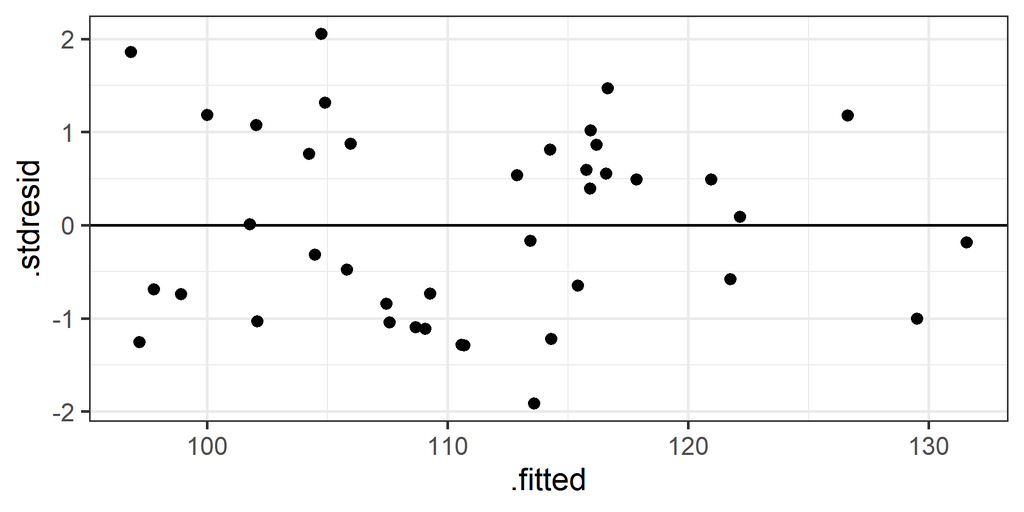

- Гетерогенность дисперсий не выражена.

## Что делать, если найдена гетероскедастичность?

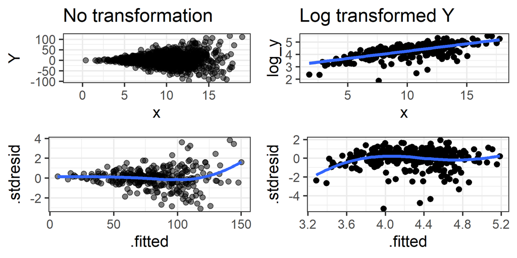

Трансформация может помочь, но лучше изменить модель.

## Возможные причины гетероскедастичности

Даже если трансформация может помочь, лучше поискать причину гетерогенности дисперсий

- Неучтенные переменные
  - добавляем в модель
- Зависимая переменная распределена по-другому
  - трансформируем данные (неудобно)
  - подбираем модель с другим распределением остатков (обобщенную линейную модель)
- Моделируем гетерогенность дисперсии.

## Самые частые паттерны в остатках

## Некоторые частые паттерны на графиках остатков

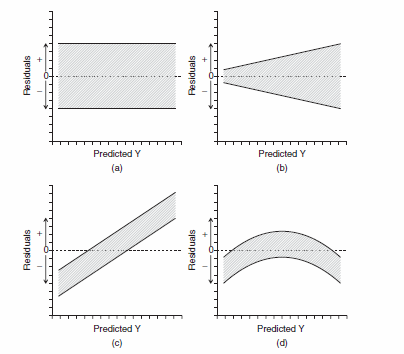

Из кн. Logan, 2010, стр. 174

- Рис. a — Условия применимости соблюдаются, модель хорошая
- Рис. b — Клиновидный паттерн. Есть гетероскедастичность. Модель плохая
- Рис. c — Остатки рассеяны равномерно, но нужны дополнительные предикторы
- Рис. d — Нелинейный паттерн. Линейная модель использована некорректно

## Зоопарк нарушений условий применимости регрессионного анализа

## Загон №1 (*Curva nonlinearis*)

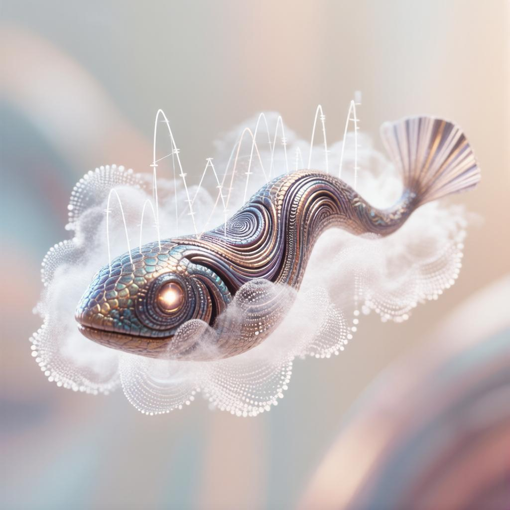

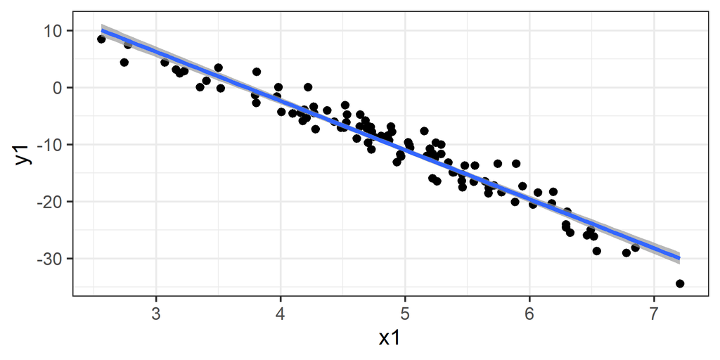

## Загон №2 (*Heteroscedastica horribilis*)

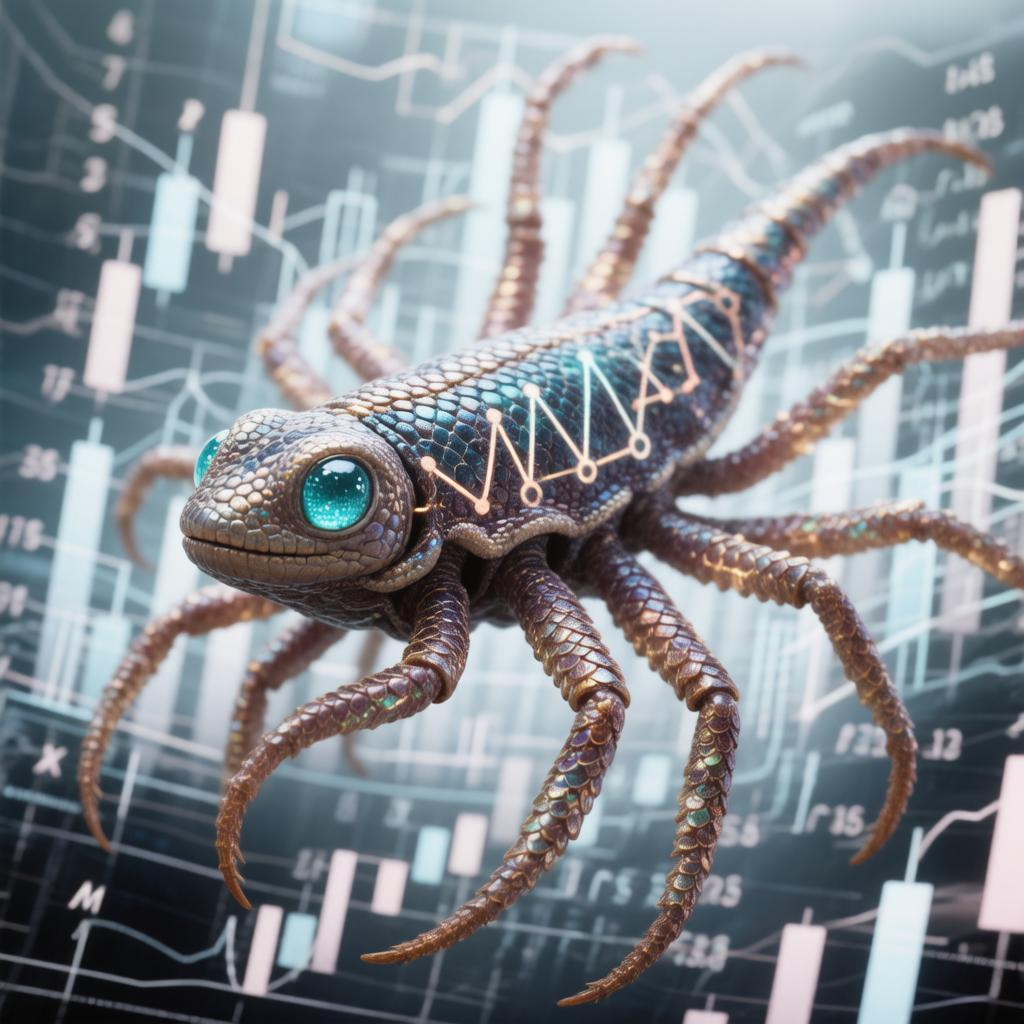

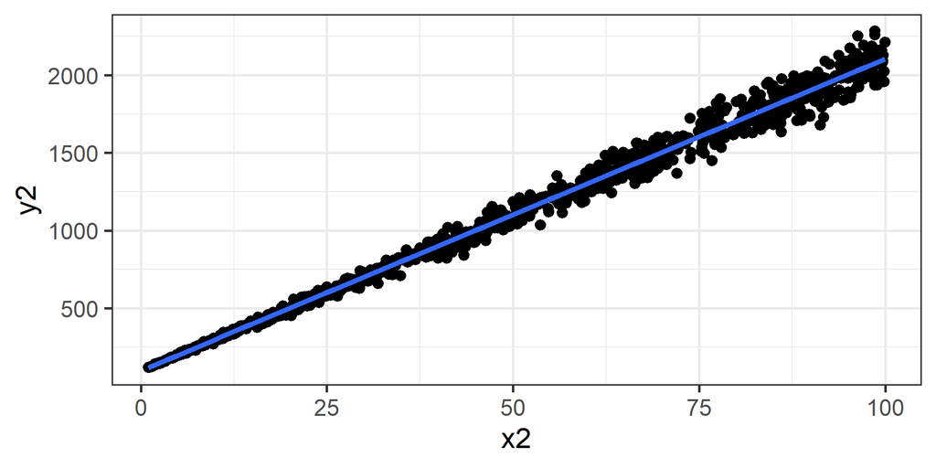

## Загон №3 (*Mensurae atypica*)

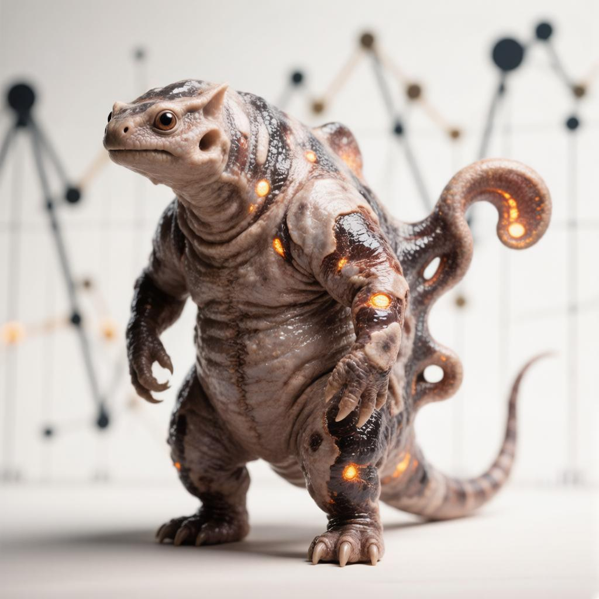

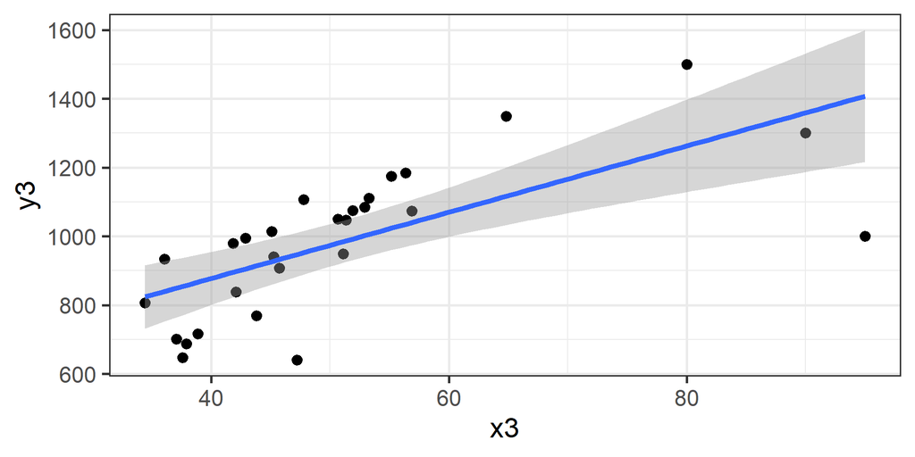

## Загон №4 (*Anima amissa*)

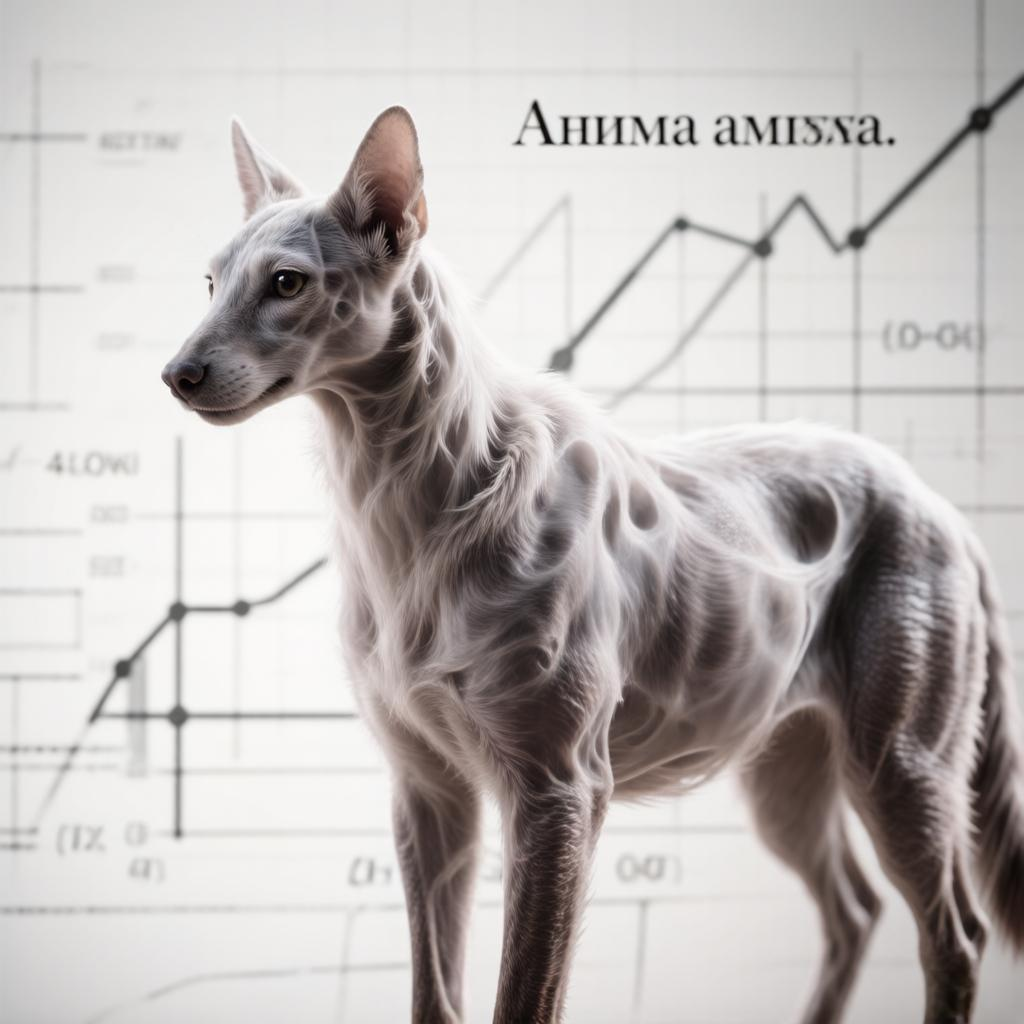

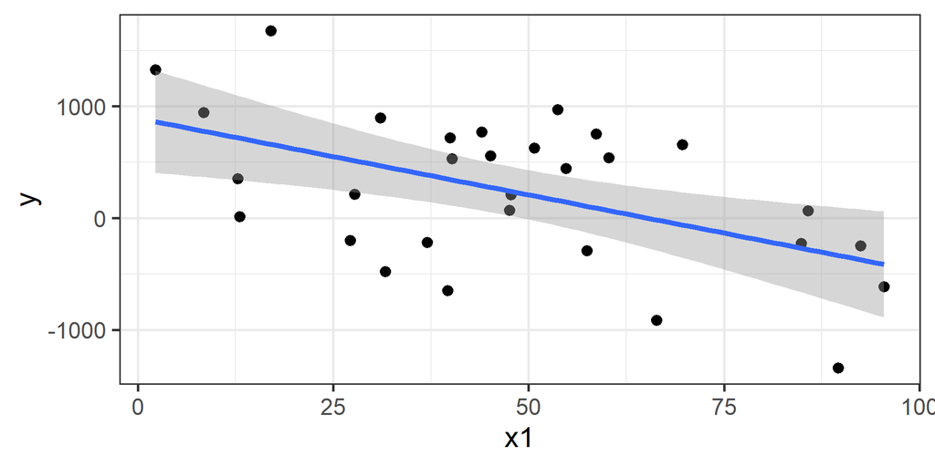

## Загон №5 (*Perdidit commercium*)

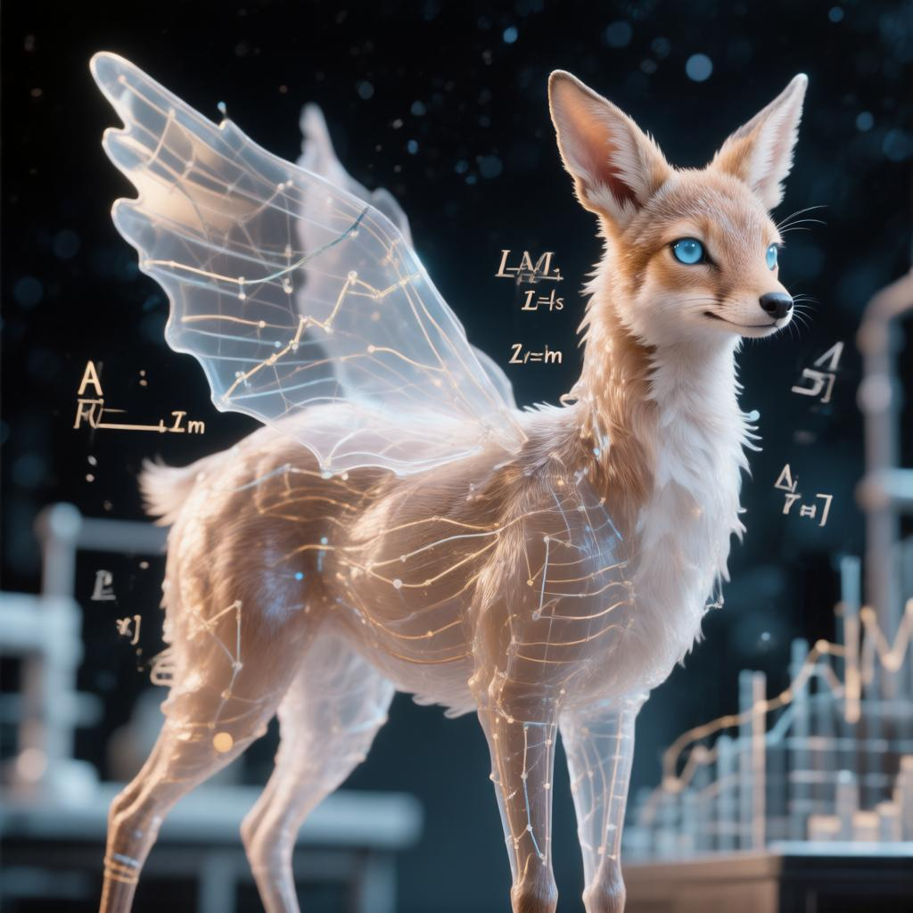

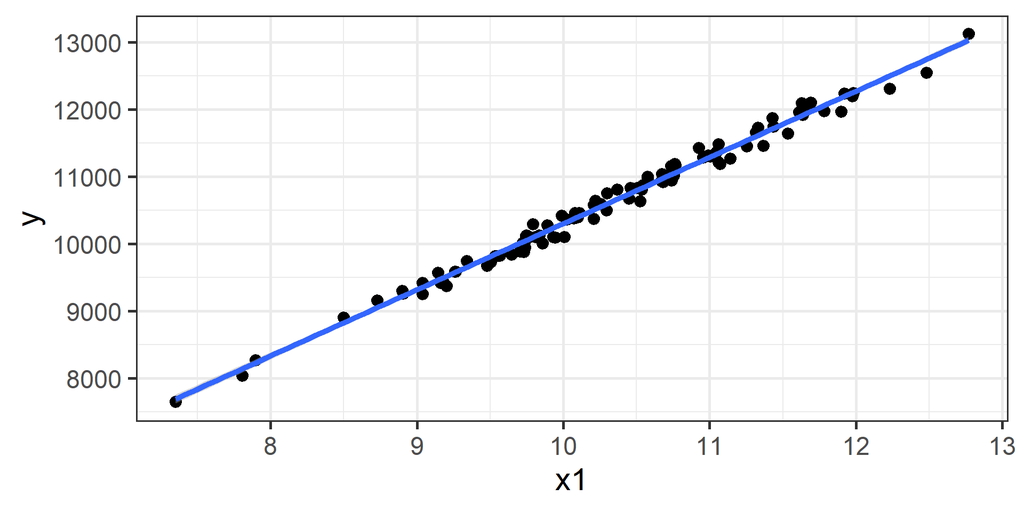

## Загон №6 (*Data longitudinalis*)

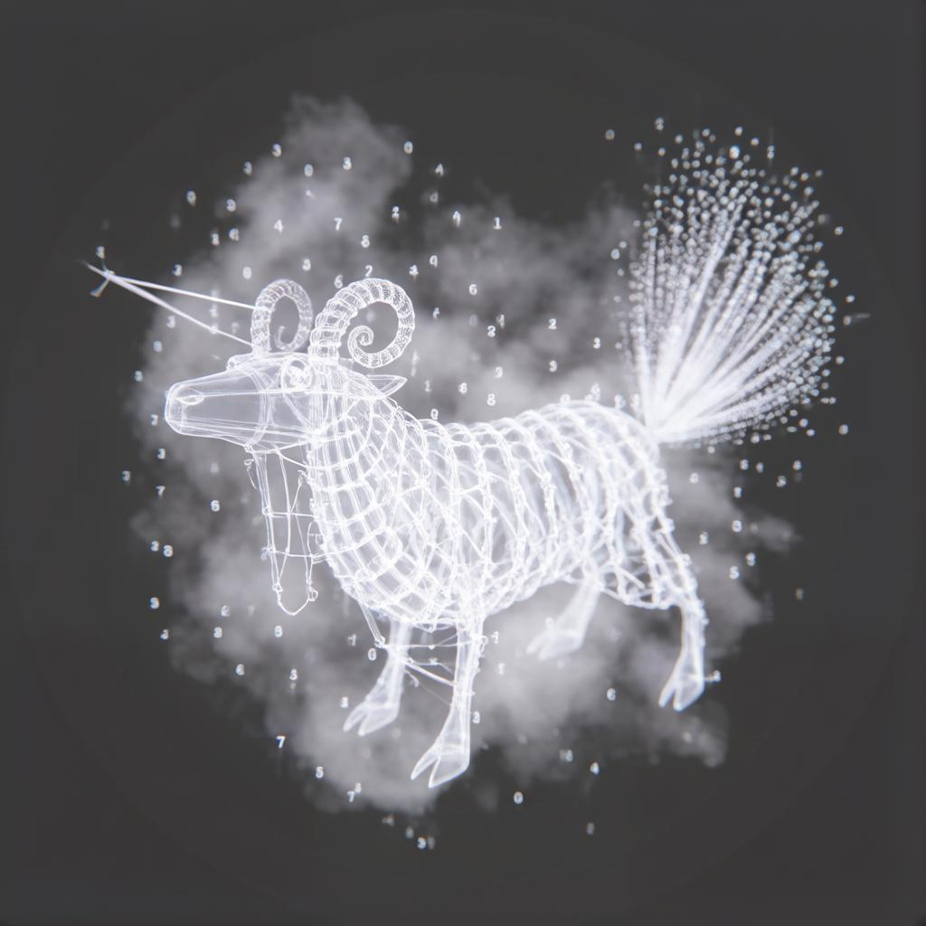

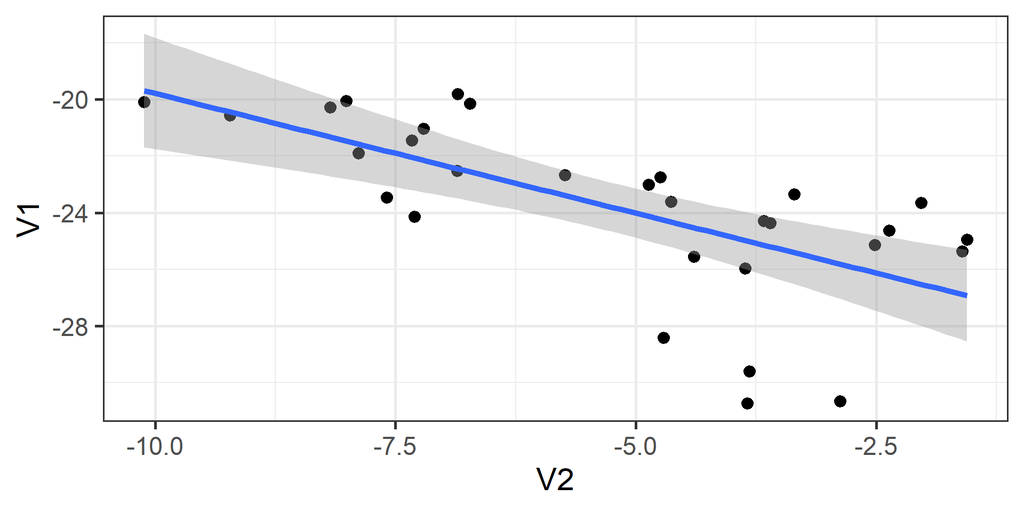

## Практикум по анализу остатков

## Задание

Выполните три блока кода

Какие нарушения условий применимости линейных моделей здесь наблюдаются?

Вам понадобятся

1. График расстояния Кука
2. График остатков от предсказанных значений
3. Графики остатков от предикторов в модели и не в модели
4. Квантильный график остатков

## Блок 1

```r
set.seed(90829)
x1 <- seq(1, 100, 1)
y1 <-  diffinv(rnorm(99))  + rnorm(100, 0.2, 4)
dat1 = data.frame(x1, y1)
ggplot(dat1, aes(x = x1, y =  y1)) + geom_point()+
  geom_smooth(method="lm", alpha = 0.7)
```

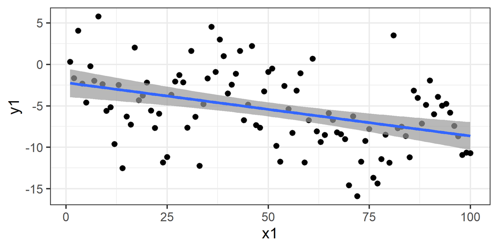

## Решение, блок 1

### Графики

```r
mod1 <- lm(y1 ~ x1, data = dat1)
mod1_diag <- fortify(mod1)
library(cowplot)
plot_grid(
  ggplot(mod1_diag, aes(x = 1:nrow(mod1_diag), y = .cooksd)) +
    geom_bar(stat = "identity"),
  ggplot(data = mod1_diag, aes(x = .fitted, y = .stdresid)) +
    geom_point() + geom_hline(yintercept = 0),
  ggplot(data = mod1_diag, aes(x = x1, y = .stdresid)) +
    geom_point() + geom_hline(yintercept = 0),
  ggplot(dat1, aes(sample = y1)) + stat_qq() + stat_qq_line(),
  nrow = 2)
```

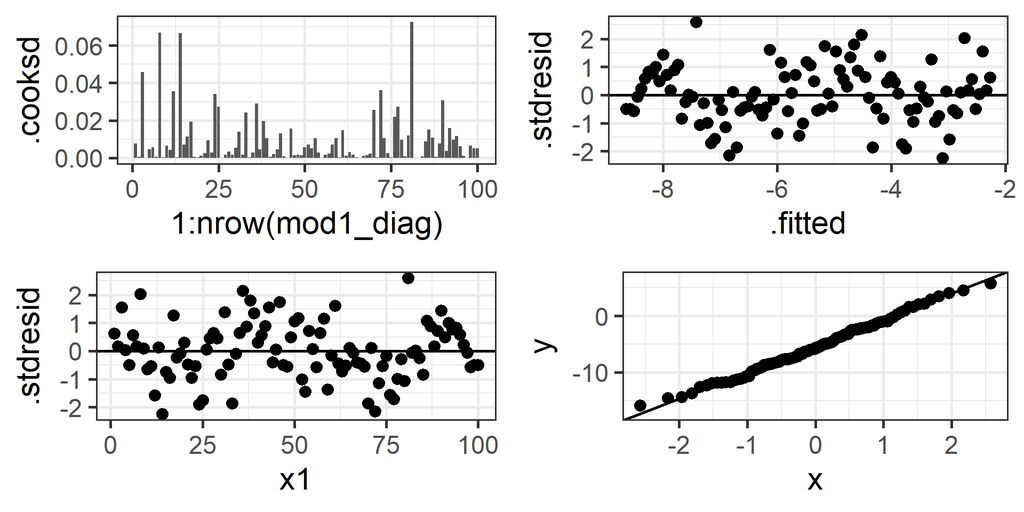

- Выбросов нет, зависимость нелинейна
- Небольшие отклонения от нормального распределения

## Решение, блок 1

```r
mod1 <- lm(y1 ~ x1, data = dat1)

# Данные для графиков остатков
mod1_diag <- fortify(mod1)

# 1) График расстояния Кука
ggplot(mod1_diag, aes(x = 1:nrow(mod1_diag), y = .cooksd)) +
  geom_bar(stat = "identity")

# 2) График остатков от предсказанных значений
gg_resid <- ggplot(data = mod1_diag, aes(x = .fitted, y = .stdresid)) +
  geom_point() + geom_hline(yintercept = 0)
gg_resid

# 3) Графики остатков от предикторов в модели и не в модели
gg_resid + aes(x = x1)

# 4) Квантильный график остатков
qqPlot(mod1, id = FALSE)
```

## Блок 2

```r
  set.seed(7657674)
  x2 <- runif(1000, 1, 100)
  b_0 <- 100;  b_1 <- -20
  h <- function(x) x^0.5
  eps <- rnorm(1000, 0, h(x2))
  y2 <- b_0 + b_1 * x2 + eps
  dat2 <- data.frame(x2, y2)
  ggplot(dat2, aes(x = x2, y = y2)) +
    geom_point() +
    geom_smooth(method = "lm")
```

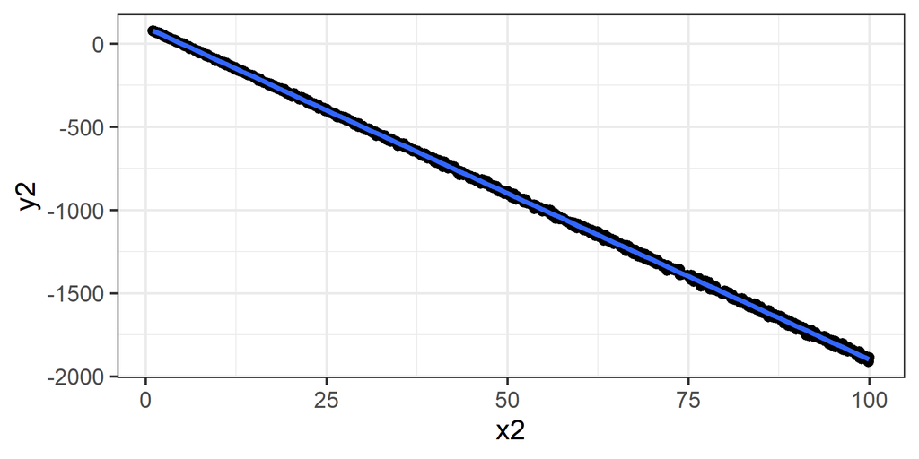

## Решение, блок 2

```r
mod2 <- lm(y2 ~ x2, data = dat2)
mod2_diag <- fortify(mod2)
plot_grid(
  ggplot(mod2_diag, aes(x = 1:nrow(mod2_diag), y = .cooksd)) +
    geom_bar(stat = "identity"),
  ggplot(data = mod2_diag, aes(x = .fitted, y = .stdresid)) +
    geom_point() + geom_hline(yintercept = 0),
  ggplot(data = mod2_diag, aes(x = x2, y = .stdresid)) +
    geom_point() + geom_hline(yintercept = 0),
  ggplot(dat2, aes(sample = y2)) + stat_qq() + stat_qq_line(),
  nrow = 2)
```

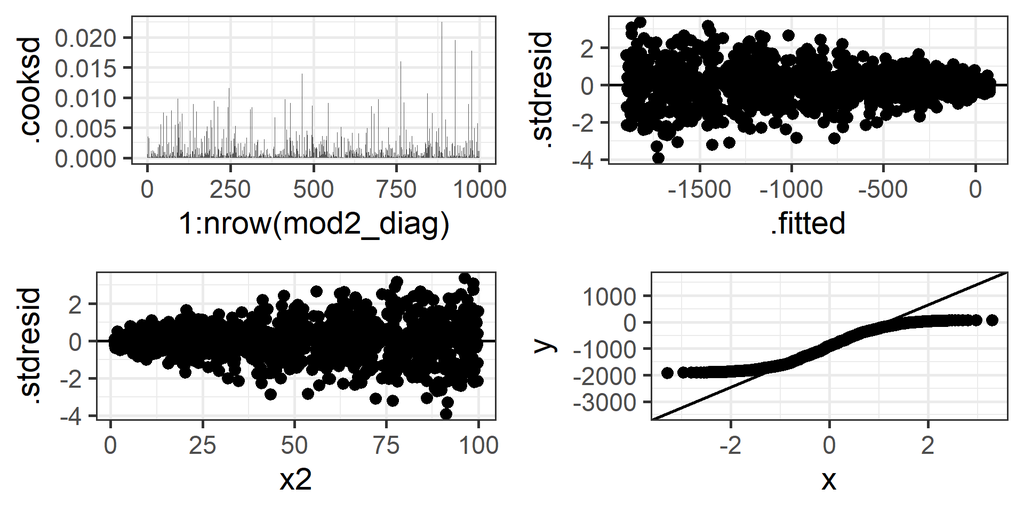

- Выбросов нет
- Гетерогенность дисперсий, остатки не подчиняются нормальному распределению

## Решение, блок 2

```r
mod2 <- lm(y2 ~ x2, data = dat2)

# Данные для графиков остатков
mod2_diag <- fortify(mod2)

# 1) График расстояния Кука
ggplot(mod2_diag, aes(x = 1:nrow(mod2_diag), y = .cooksd)) +
  geom_bar(stat = "identity")

# 2) График остатков от предсказанных значений
gg_resid <- ggplot(data = mod2_diag, aes(x = .fitted, y = .stdresid)) +
  geom_point() + geom_hline(yintercept = 0)
gg_resid

# 3) Графики остатков от предикторов в модели и не в модели
gg_resid + aes(x = x2)

# 4) Квантильный график остатков
qqPlot(mod2, id = FALSE)
```

## Блок 3

```r
set.seed(9283)
x3 <- rnorm(25, 50, 10)
b_0 <- 20; b_1 <- 20; eps <- rnorm(50, 0, 100)
y3 <- b_0 + b_1*x3 + eps
y3[100] <- 1000; x3[100] <- 95; y3[99] <- 1300; x3[99] <- 90; y3[98] <- 1500; x3[98] <- 80
dat3 <- data.frame(x3, y3)
ggplot(dat3, aes(x=x3, y=y3)) + geom_point() + geom_smooth(method="lm")
```

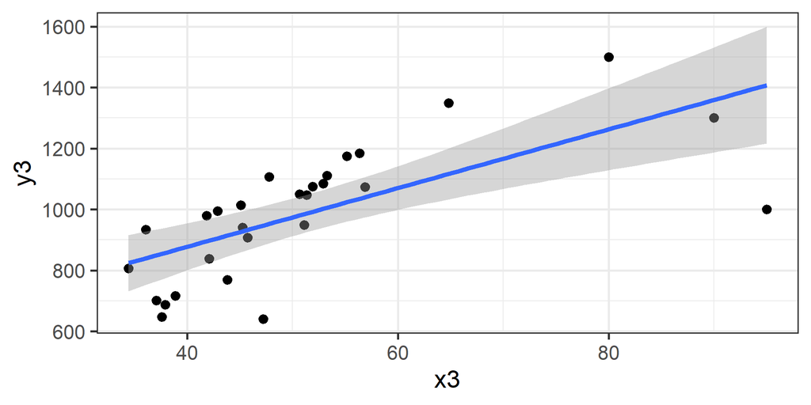

## Решение, блок 3

```r
mod3 <- lm(y3 ~ x3, data = dat3)
mod3_diag <- fortify(mod3)
plot_grid(
  ggplot(mod3_diag, aes(x = 1:nrow(mod3_diag), y = .cooksd)) +
    geom_bar(stat = "identity"),
  ggplot(data = mod3_diag, aes(x = .fitted, y = .stdresid)) +
    geom_point() + geom_hline(yintercept = 0),
  ggplot(data = mod3_diag, aes(x = x3, y = .stdresid)) +
    geom_point() + geom_hline(yintercept = 0),
  ggplot(dat2, aes(sample = y2)) + stat_qq() + stat_qq_line(),
  nrow = 2)
```

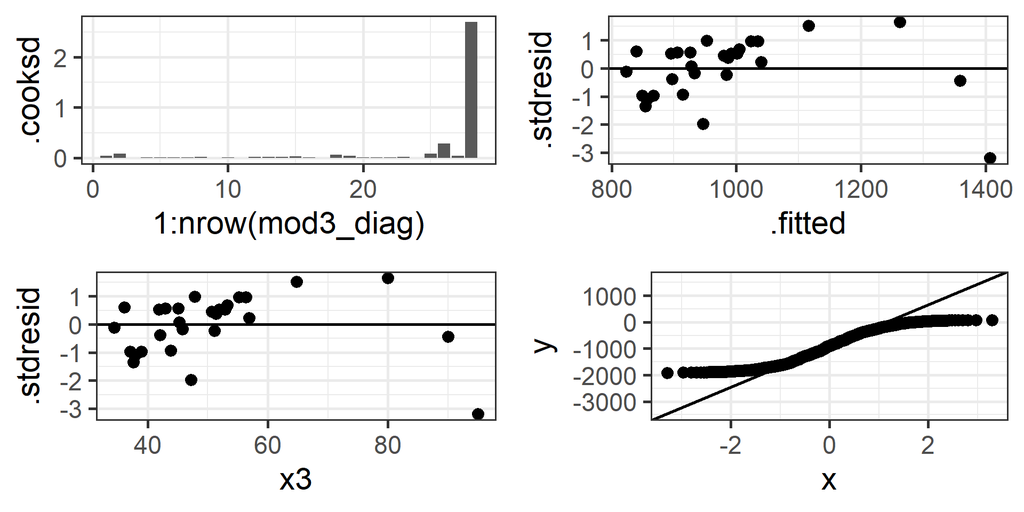

- 100-е наблюдение сильно влияет на ход регрессии
- Зависимость может быть нелинейна

## Решение, блок 3

```r
mod3 <- lm(y3 ~ x3, data = dat3)

# Данные для графиков остатков
mod3_diag <- fortify(mod3)

# 1) График расстояния Кука
ggplot(mod3_diag, aes(x = 1:nrow(mod3_diag), y = .cooksd)) +
  geom_bar(stat = "identity")

# 2) График остатков от предсказанных значений
gg_resid <- ggplot(data = mod3_diag, aes(x = .fitted, y = .stdresid)) +
  geom_point() + geom_hline(yintercept = 0)
gg_resid

# 3) Графики остатков от предикторов в модели и не в модели
gg_resid + aes(x = x3)

# 4) Квантильный график остатков
qqPlot(mod3, id = FALSE)
```

## Задание для самостоятельной работы

Выполните последнее задание в одном из этих файлов: - 07_task_assumptions_catsM.R - 07_task_assumptions_GAG.R

## Take-home messages

- Гипотезы о наличии зависимости можно тестировать при помощи t- или F-теста.
- Качество подгонки модели можно оценить при помощи коэффициента детерминации $R^2$.
- У линейных моделей есть условия применимости, поэтому не спешите описывать результаты — сначала проверьте.
- Если условия применимости нарушены, то результатам тестов для этой модели нельзя верить (получаются заниженные доверительные вероятности, возрастает вероятность ошибок I рода).
- Анализ остатков дает разностороннюю информацию о валидности моделей.

## Что почитать

- Гланц, С., 1998. Медико-биологическая статистика. М., Практика
- Кабаков Р.И. R в действии. Анализ и визуализация данных на языке R. М.: ДМК Пресс, 2014
- Diez, D.M., Barr, C.D. and Çetinkaya-Rundel, M., 2015. OpenIntro Statistics. OpenIntro.
- Zuur, A., Ieno, E.N. and Smith, G.M., 2007. Analyzing ecological data. Springer Science & Business Media.
- Quinn G.P., Keough M.J. 2002. Experimental design and data analysis for biologists
- Logan M. 2010. Biostatistical Design and Analysis Using R. A Practical Guide